# Horsepower and Acceleration

Jacob Park

## Introduction

For this project, I decided to see the relationship between the category of vehicles with the horsepower and acceleration. Since vehicles are comprised of many different engineering feats, this project explores the relationship between mostly the horsepower and acceleration. Since many people believe that with horsepower is positively correlated with acceleration, I wanted to see if there actually was a correlation between just horsepower and acceleration. I will also be exploring the two variables between the different brands as well. I believe that horsepower is not positively correlated with acceleration, performance category vehicles will have faster acceleration, and BMW will have the highest focus on horsepower since they are very driver-centric.

## Methods

I gathered my data using a variety of well-known automobile manufacturers from low budget to luxury brands. This will give a wide scope of data and will give interesting input on the difference between budget and luxury car brands. For the actual vehicles, I used every vehicle in the vehicle lineup as of today, April 7th, 2018. This will give a modern snapshot of what everything looks like today. I have a mixed variety of cars from Sedans and SUVs to even performance vehicles.

## Data Dictionary:

-**make**: a character variable describing the brand of the vehicle.

-**model**: a character variable describing the specific model of the vehicle.

-**category**: a categorical variable describing the vehicle class. Possible choices are:

- SEDAN
- SUV
- HATCHBACK
- PERFORMANCE

-**horsepower**: a numerical variable containing the horsepower of the base model

-**acceleration**: a numerical variable containing the 0-60 mph acceleration time. (in  
seconds)

## Results

```
##
## Call:
## lm_basic(formula = acceleration ~ 1 + horsepower, data = cars)
##
## Residuals:
##     Min      1Q  Median      3Q     Max
## -2.0710 -0.6677 -0.0544  0.5873  2.7555
##
## Coefficients:
##             Estimate    2.5 % 97.5 %
## (Intercept) 10.16463  9.66544 10.664
## horsepower  -0.01333 -0.01511 -0.012
##
## Residual standard error: 0.9554 on 98 degrees of freedom
## Multiple R-squared:  0.6933, Adjusted R-squared:  0.6902
## F-statistic: 221.6 on 1 and 98 DF,  p-value: < 2.2e-16
```

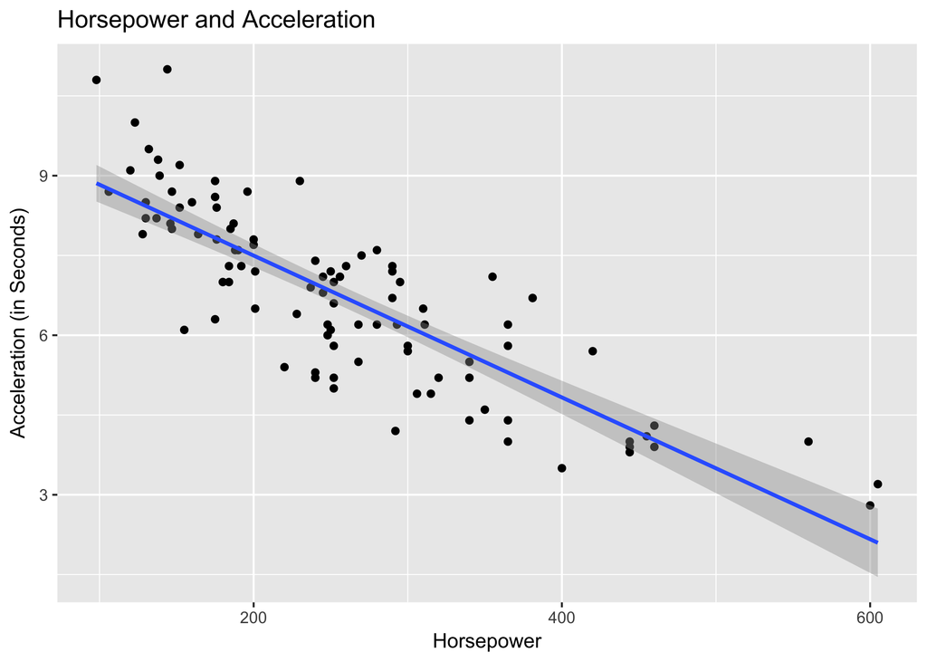

This output shows the relationship between horsepower and acceleration. The line shown in the plot is the regression line. The confidence interval level used is 95% and will be 95% for all the graphs below.

```
##
## Call:
## lm_basic(formula = acceleration ~ 1 + category, data = cars)
##
## Residuals:
##     Min      1Q  Median      3Q     Max
## -2.4824 -0.8838 -0.1881  0.8119  3.7119
##
## Coefficients:
##                     Estimate  2.5 % 97.5 %
## (Intercept)            8.680  7.501  9.859
## categoryPERFORMANCE   -4.122 -5.447 -2.797
## categorySEDAN         -1.798 -3.060 -0.535
## categorySUV           -1.392 -2.639 -0.145
##
## Residual standard error: 1.328 on 96 degrees of freedom
## Multiple R-squared:  0.4198, Adjusted R-squared:  0.4017
## F-statistic: 23.15 on 3 and 96 DF,  p-value: 2.322e-11
```

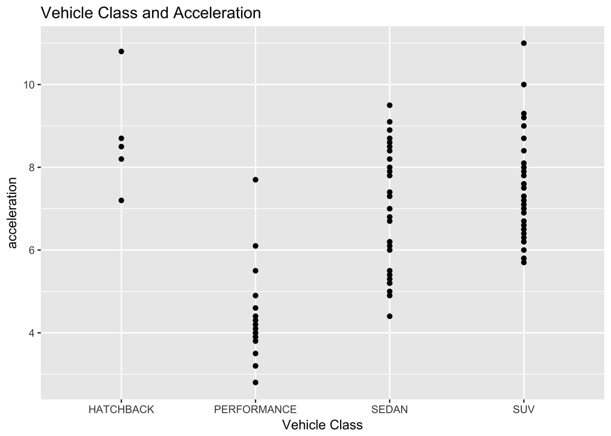

This output shows the relationship between the category of vehicles and their acceleration. The intercept here is the category hatchback. This is the baseline because they are the slowest acceleration category. The mean of the hatchback could be anywhere between 7.501 and 9.859. Since the performance category has a slope of anywhere between -5.447 and -2.797, it is the fastest accelerating cateogry.

```
##
## Call:
## lm_basic(formula = horsepower ~ 1 + make, data = cars)
##
## Residuals:
##     Min      1Q  Median      3Q     Max
## -181.18  -70.23  -22.00   63.71  282.77
##
## Coefficients:
##               Estimate   2.5 % 97.5 %
## (Intercept)     322.23  267.83 376.63
## makeBMW          17.77  -56.55  92.09
## makeCHEVROLET   -43.05 -123.40  37.30
## makeFORD        -66.31 -144.83  12.20
## makeHONDA      -109.23 -206.03 -12.43
## makeHYUNDAI    -109.98 -198.12 -21.85
## makeKIA         -92.73 -175.23 -10.23
## makeMAZDA      -137.90 -234.70 -41.10
## makeSUBARU     -117.48 -205.62 -29.35
## makeTOYOTA      -92.32 -172.67 -11.97
##
## Residual standard error: 98.72 on 90 degrees of freedom
## Multiple R-squared:  0.2287, Adjusted R-squared:  0.1516
## F-statistic: 2.965 on 9 and 90 DF,  p-value: 0.003919
```

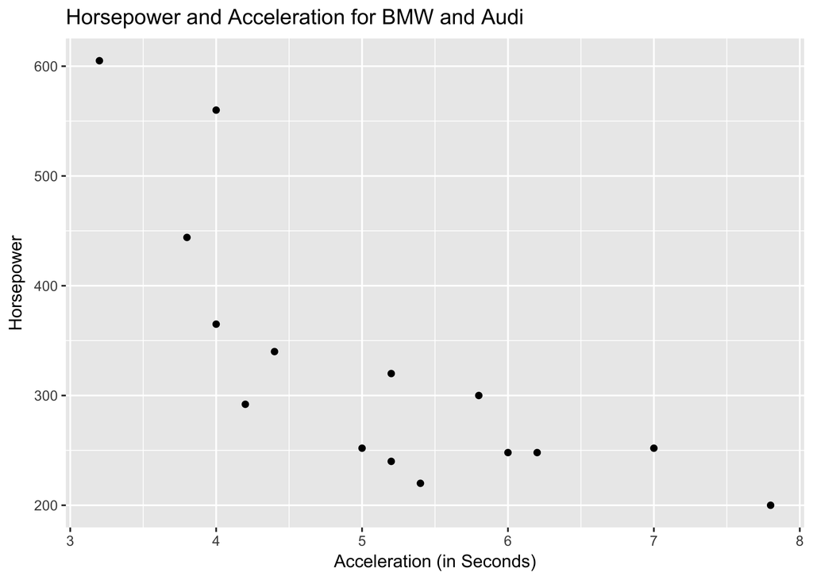

This analysis shows the relationship between the car manufacturers and the horsepower. The baseline used was Audi and it can have a mean horsepower of anywhere between 267.83 and 376.63. BMW can have a slope of anywhere between -56.55 and 92.09.

## Conclusions

According to the first analysis, as the horsepower increases, the acceleration time decreases. This decrease is significant, because the confidence intervals do not contain 0, but it is a very minor slope. However, as the horsepower increases by 1, it can be very roughly estimated that acceleration will decrease by 0.01333 seconds. My original hypothesis was incorrect and actually happened to be the other way around.

## References

“Car Reviews - New Cars for 2016 and 2017 at Car and Driver.” Car and Driver, www.caranddriver.com/.